# Chapter 10 R lecture notes

Loren Serfass

03/21/2015

# Principal Components

```r
?USArrests # Arrests per 100,000 residents in 1973 in each state
dimnames(USArrests)
```

```
## [[1]]
##  [1] "Alabama"        "Alaska"         "Arizona"        "Arkansas"
##  [5] "California"     "Colorado"       "Connecticut"    "Delaware"
##  [9] "Florida"        "Georgia"        "Hawaii"         "Idaho"
## [13] "Illinois"       "Indiana"        "Iowa"           "Kansas"
## [17] "Kentucky"       "Louisiana"      "Maine"          "Maryland"
## [21] "Massachusetts"  "Michigan"       "Minnesota"      "Mississippi"
## [25] "Missouri"       "Montana"        "Nebraska"       "Nevada"
## [29] "New Hampshire"  "New Jersey"     "New Mexico"     "New York"
## [33] "North Carolina" "North Dakota"   "Ohio"           "Oklahoma"
## [37] "Oregon"         "Pennsylvania"   "Rhode Island"   "South Carolina"
## [41] "South Dakota"   "Tennessee"      "Texas"          "Utah"
## [45] "Vermont"        "Virginia"       "Washington"     "West Virginia"
## [49] "Wisconsin"      "Wyoming"
##
## [[2]]
## [1] "Murder"   "Assault"  "UrbanPop" "Rape"
```

```r
head(USArrests)
```

```
##            Murder Assault UrbanPop Rape
## Alabama      13.2     236       58 21.2
## Alaska       10.0     263       48 44.5
## Arizona       8.1     294       80 31.0
## Arkansas      8.8     190       50 19.5
## California    9.0     276       91 40.6
## Colorado      7.9     204       78 38.7
```

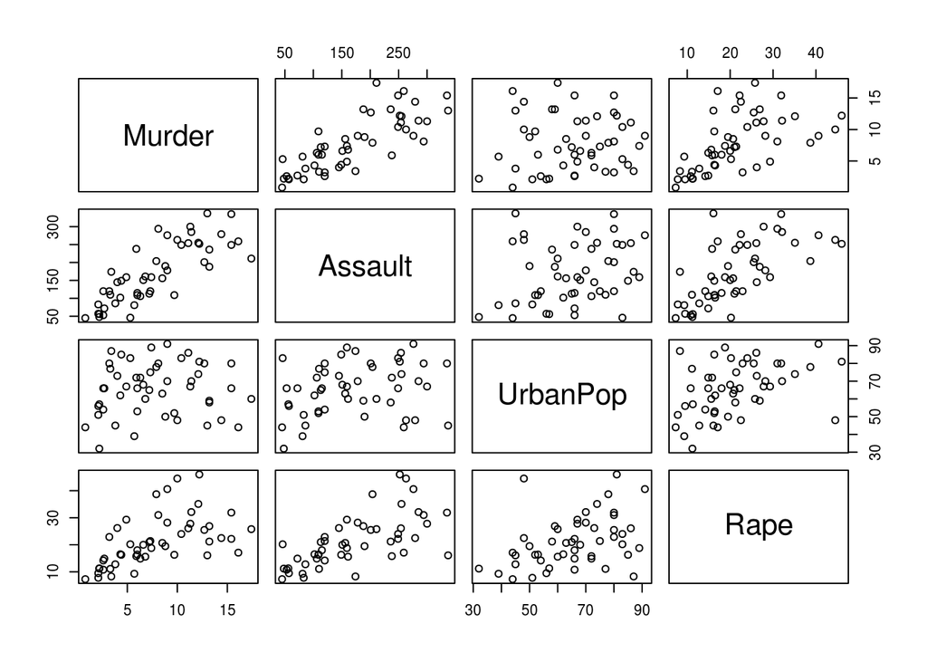

```r
pairs(USArrests)
```

```r
(m <- apply(USArrests,2,mean)) # means of the columns
```

```
##   Murder  Assault UrbanPop     Rape
##    7.788  170.760   65.540   21.232
```

```r
# apply(USArrests,2,var) # variances of the columns
(s <- apply(USArrests,2,sd)) # sd of the columns
```

```
##   Murder  Assault UrbanPop     Rape
##    4.356   83.338   14.475    9.366
```

`Assault` has a larger mean and standard deviation than the other variables. We standardize the variables to do PCA.

```r
(pca.out <- prcomp(USArrests, scale=TRUE)) # scale=TRUE standardizes the variables
```

```
## Standard deviations:
## [1] 1.5749 0.9949 0.5971 0.4164
##
## Rotation:
##              PC1     PC2     PC3      PC4
## Murder   -0.5359  0.4182 -0.3412  0.64923
## Assault  -0.5832  0.1880 -0.2681 -0.74341
## UrbanPop -0.2782 -0.8728 -0.3780  0.13388
## Rape     -0.5434 -0.1673  0.8178  0.08902
```

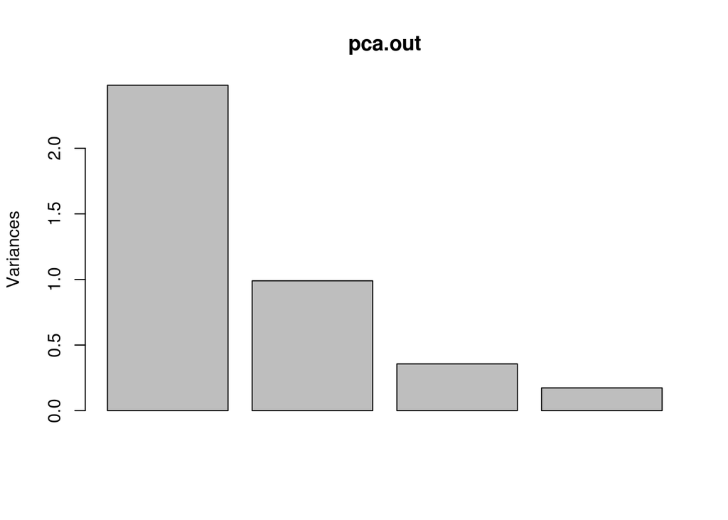

```r
plot(pca.out) # just plots the strength of each component
```

```r
summary(pca.out)
```

```
## Importance of components:
##                         PC1   PC2    PC3    PC4
## Standard deviation     1.57 0.995 0.5971 0.4164
## Proportion of Variance 0.62 0.247 0.0891 0.0434
## Cumulative Proportion  0.62 0.868 0.9566 1.0000
```

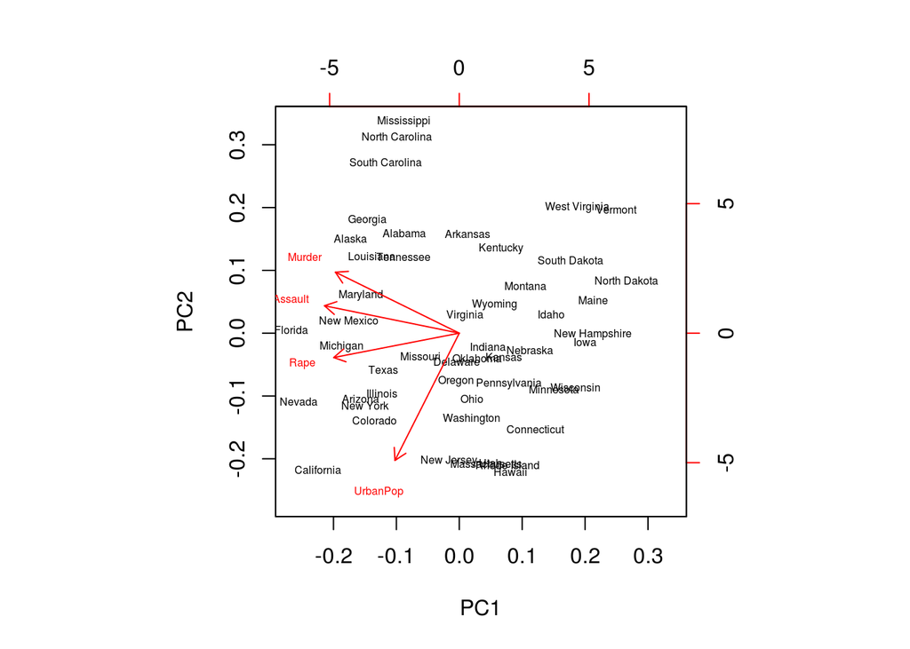

```r
biplot(pca.out, cex=.5)
```

The `biplot` shows that the horizontal axis (`PC1`) is mostly due to murder, assault, and rape. The states on the left, aligning with the red arrows, are high-crime. The vertical axis is mostly about whether the state has a high or low urban population.

# Figuring out the prcomp object produced by the prcomp call

I did this by myself.

- `center` is the column means of the original data
- `scale` is the column standard deviations of the original data
- The columns of `rotation` are vectors of length 1. These are the principal components vectors.
- `sdev` is the column-wise standard deviations of `x`

```r
names(pca.out)
```

```
## [1] "sdev"     "rotation" "center"   "scale"    "x"
```

```r
identical(pca.out$center, apply(USArrests,2,mean))
```

```
## [1] TRUE
```

```r
identical(pca.out$scale, apply(USArrests,2,sd))
```

```
## [1] TRUE
```

```r
apply(pca.out$rotation, 2, function(y) sqrt(sum(y^2))) # columns are vectors of length 1
```

```
## PC1 PC2 PC3 PC4
##   1   1   1   1
```

```r
all.equal(pca.out$sdev, apply(pca.out$x, 2, sd))
```

```
## [1] "names for current but not for target"
```

The `rotation` matrix is the “loadings.” For instance, the first column is the direction of the first principal component.

# Recovering the original data (manually)

I figured this out by myself.

```r
step1 <- pca.out$x %*% t(pca.out$rotation) # rotating to original axes
step2 <- sweep(step1, 2, s, "*") # scaling the columns back to original standard deviations
step3 <- sweep(step2, 2, m, "+") # centering the columns around their original means
all.equal(as.matrix(USArrests), step3, check.attributes=F) # They have the same numbers and names
```

```
## [1] TRUE
```

# Quiz questions :-(

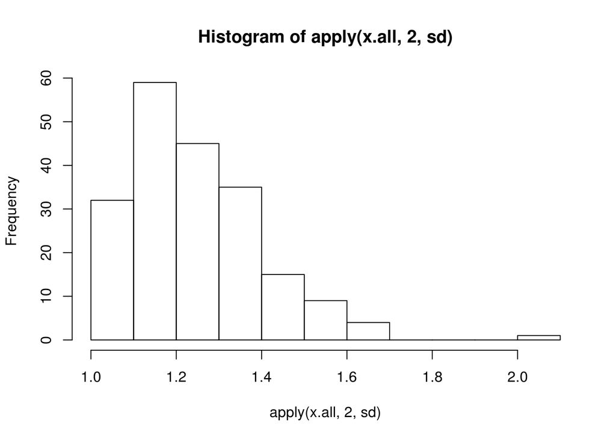

```r
load('10.R.RData') # loads x, x.test, y, y.test
# x is 300 obs of 200 vars
# x.test is 1000 obs of 200 vars
x.all <- rbind(x, x.test)
hist(apply(x.all,2,sd)) # the standard deviations of the columns
```

```r
x.prcomp <- prcomp(x.all, scale=T)
summary(x.prcomp) # This gives the cumulative proportion of variance explained
```

```
## Importance of components:
##                          PC1   PC2    PC3    PC4    PC5     PC6     PC7
## Standard deviation     5.056 4.597 3.7229 2.6971 1.4631 1.16827 1.15848
## Proportion of Variance 0.128 0.106 0.0693 0.0364 0.0107 0.00682 0.00671
## Cumulative Proportion  0.128 0.233 0.3028 0.3392 0.3499 0.35668 0.36339
##                            PC8     PC9    PC10    PC11    PC12    PC13
## Standard deviation     1.15544 1.14591 1.13933 1.13619 1.13190 1.11047
## Proportion of Variance 0.00668 0.00657 0.00649 0.00645 0.00641 0.00617
## Cumulative Proportion  0.37007 0.37663 0.38312 0.38958 0.39598 0.40215
##                           PC14    PC15    PC16    PC17   PC18    PC19
## Standard deviation     1.10810 1.10226 1.09960 1.09257 1.0862 1.08519
## Proportion of Variance 0.00614 0.00607 0.00605 0.00597 0.0059 0.00589
## Cumulative Proportion  0.40829 0.41436 0.42041 0.42638 0.4323 0.43816
##                           PC20    PC21    PC22    PC23   PC24    PC25
## Standard deviation     1.07475 1.06942 1.06265 1.05967 1.0579 1.05436
## Proportion of Variance 0.00578 0.00572 0.00565 0.00561 0.0056 0.00556
## Cumulative Proportion  0.44394 0.44966 0.45530 0.46092 0.4665 0.47207
##                           PC26    PC27    PC28    PC29   PC30    PC31
## Standard deviation     1.04973 1.04615 1.04513 1.03557 1.0294 1.02468
## Proportion of Variance 0.00551 0.00547 0.00546 0.00536 0.0053 0.00525
## Cumulative Proportion  0.47758 0.48306 0.48852 0.49388 0.4992 0.50443
##                           PC32    PC33    PC34    PC35    PC36    PC37
## Standard deviation     1.02362 1.02126 1.01749 1.01436 1.01115 1.00510
## Proportion of Variance 0.00524 0.00521 0.00518 0.00514 0.00511 0.00505
## Cumulative Proportion  0.50967 0.51488 0.52006 0.52520 0.53031 0.53536
##                         PC38    PC39    PC40    PC41    PC42    PC43
## Standard deviation     1.000 0.99711 0.99421 0.99132 0.98549 0.98031
## Proportion of Variance 0.005 0.00497 0.00494 0.00491 0.00486 0.00481
## Cumulative Proportion  0.540 0.54534 0.55028 0.55519 0.56005 0.56485
##                          PC44    PC45    PC46    PC47    PC48    PC49
## Standard deviation     0.9797 0.97717 0.97387 0.96814 0.95762 0.95609
## Proportion of Variance 0.0048 0.00477 0.00474 0.00469 0.00459 0.00457
## Cumulative Proportion  0.5696 0.57443 0.57917 0.58386 0.58844 0.59301
##                           PC50    PC51    PC52    PC53    PC54    PC55
## Standard deviation     0.95320 0.95162 0.94967 0.94648 0.94083 0.93936
## Proportion of Variance 0.00454 0.00453 0.00451 0.00448 0.00443 0.00441
## Cumulative Proportion  0.59756 0.60208 0.60659 0.61107 0.61550 0.61991
##                           PC56    PC57    PC58    PC59    PC60    PC61
## Standard deviation     0.93189 0.92636 0.92578 0.92296 0.91955 0.91776
## Proportion of Variance 0.00434 0.00429 0.00429 0.00426 0.00423 0.00421
```

[output cut: 82 more lines]

```
## Standard deviation     0.54912 0.54679 0.54492 0.54137 0.53964 0.53536
## Proportion of Variance 0.00151 0.00149 0.00148 0.00147 0.00146 0.00143
## Cumulative Proportion  0.97642 0.97791 0.97940 0.98086 0.98232 0.98375
##                          PC188   PC189   PC190   PC191   PC192  PC193
## Standard deviation     0.52646 0.52444 0.52070 0.51532 0.51244 0.5106
## Proportion of Variance 0.00139 0.00138 0.00136 0.00133 0.00131 0.0013
## Cumulative Proportion  0.98514 0.98651 0.98787 0.98920 0.99051 0.9918
##                          PC194   PC195   PC196   PC197   PC198   PC199
## Standard deviation     0.50301 0.50114 0.49116 0.48723 0.48489 0.48099
## Proportion of Variance 0.00127 0.00126 0.00121 0.00119 0.00118 0.00116
## Cumulative Proportion  0.99308 0.99433 0.99554 0.99673 0.99790 0.99906
##                          PC200
## Standard deviation     0.43382
## Proportion of Variance 0.00094
## Cumulative Proportion  1.00000
```

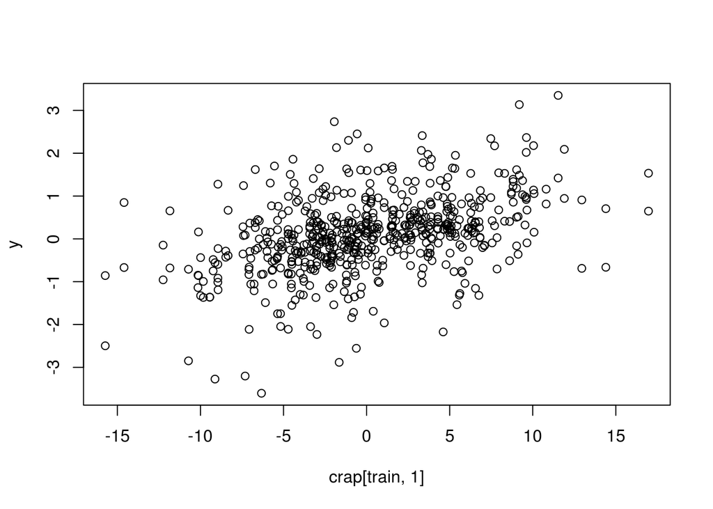

```r
vars = prcomp(rbind(x,x.test),scale=TRUE)$sdev^2 # can't figure out the relevance of this

crap <- data.frame(x.prcomp$x)

train <- 1:300
n.pr.cp <- 10

mod <- lm(y ~ ., data=crap[train,1:n.pr.cp]) # doesn't work when n.pr.cp = 1
# pred.train <- predict(mod, newdata=crap[train,1])
pred.train <- mod$coefficients[1] +
    as.matrix(crap[train,1:n.pr.cp]) %*% mod$coefficients[-1]
plot(crap[train,1], y)
points(crap[train,1], pred.train)
```

```r
mean((y - pred.train)^2)
```

```
## [1] 1.079
```

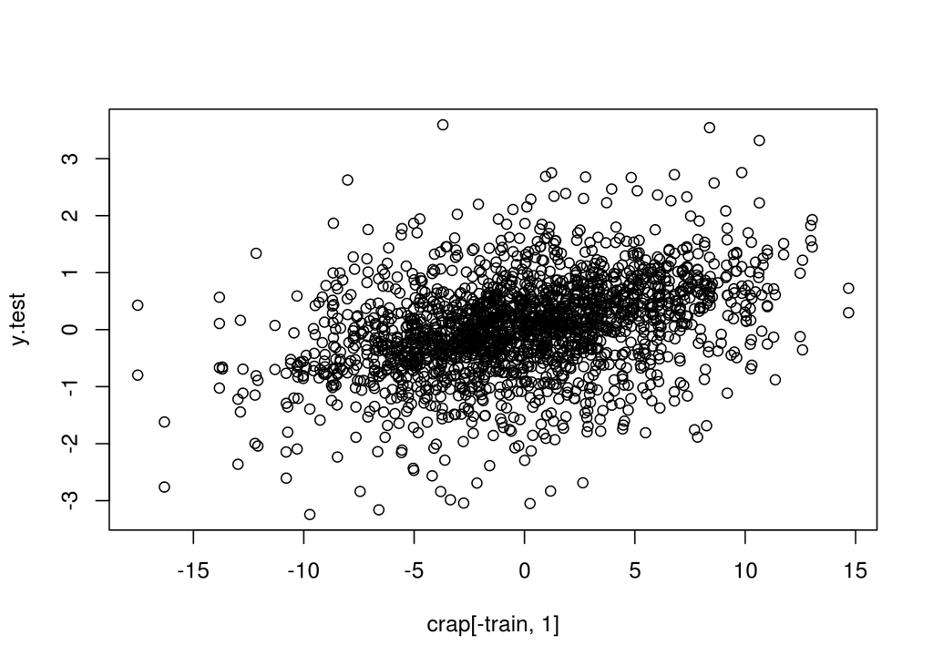

```r
pred.test <- mod$coefficients[1] +
    as.matrix(crap[-train,1:n.pr.cp]) %*% mod$coefficients[-1]
plot(crap[-train,1], y.test)
points(crap[-train,1], pred.test)
```

```r
mean((y.test-pred.test)^2)
```

```
## [1] 1.013
```

```r
get.errors <- function(n.pr.cp) { # n.pr.cp is the number of prin comp used
    mod <- lm(y ~ ., data=crap[train,1:n.pr.cp])
    pred.train <- mod$coefficients[1] +
        as.matrix(crap[train,1:n.pr.cp]) %*% mod$coefficients[-1]
    pred.test <- mod$coefficients[1] +
        as.matrix(crap[-train,1:n.pr.cp]) %*% mod$coefficients[-1]
    train.mse <- mean((y-pred.train)^2) # mean squared error
    test.mse <- mean((y.test - pred.test)^2)
    list(train.mse, test.mse)
}
get.errors(5)
```

```
## [[1]]
## [1] 1.094
##
## [[2]]
## [1] 0.9923
```

```r
# regressing on the original data
mod.hell <- lm(y ~ ., data=x)
pred.test <- mod.hell$coefficients[1] +
    as.matrix(x.test) %*% mod.hell$coefficients[-1]
mean((y.test-pred.test)^2)
```

```
## [1] 3.657
```

# K-means clustering

Making fake data in 2 dimensions (for making pictures):

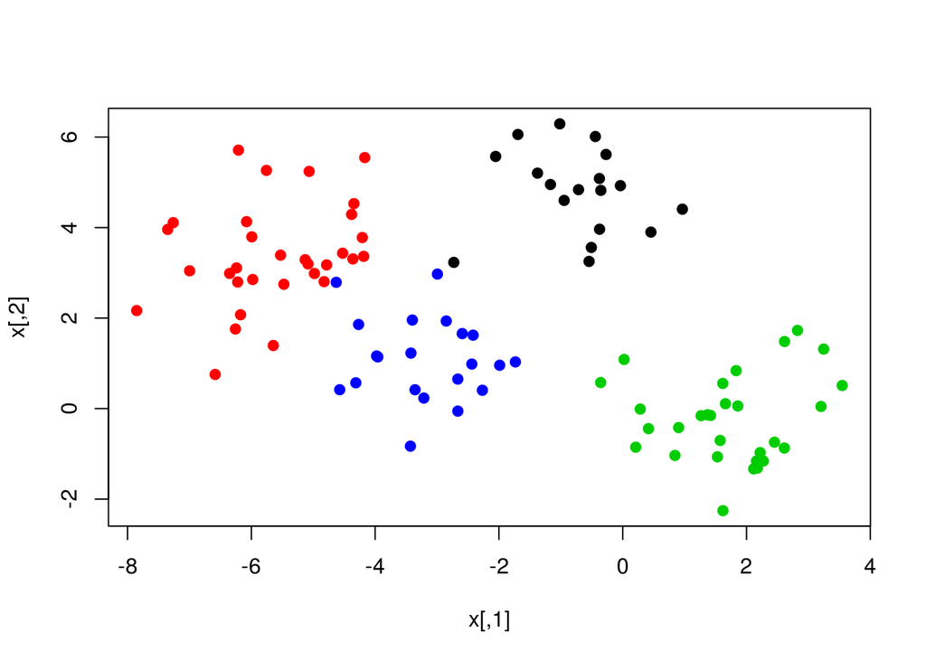

```r
mean.sep <- 4 # sort of like saying how much the means are separated
set.seed(101)
x <- matrix(rnorm(100*2),100,2) # starting with the random deviations from group means
xmean <- matrix(rnorm(8,sd=mean.sep),4,2) # there will be 4 different means
which <- sample(1:4, 100, replace=T) # assigning group to observation
x <- x + xmean[which,] # adding the group means
plot(x, col=which, pch=19) # the random data we have created
```

We know the “true” means, but won’t tell them to the `kmeans` algorithm.

```r
km.out <- kmeans(x,4,nstart=15) # try it 15 times with 15 different random starts
km.out
```

```
## K-means clustering with 4 clusters of sizes 21, 30, 32, 17
##
## Cluster means:
##      [,1]    [,2]
## 1 -3.1069  1.1213
## 2  1.7226 -0.2585
## 3 -5.5818  3.3685
## 4 -0.6148  4.8861
##
## Clustering vector:
##   [1] 2 3 3 4 1 1 4 3 2 3 2 1 1 3 1 1 2 3 3 2 2 3 1 3 1 1 2 2 3 1 1 4 3 1 3
##  [36] 3 1 2 2 3 2 2 3 3 1 3 1 3 4 2 1 2 2 4 3 3 2 2 3 2 1 2 3 4 2 4 3 4 4 2
##  [71] 2 4 3 2 3 4 4 2 2 1 2 4 4 3 3 2 3 3 1 2 3 2 4 4 4 2 3 3 1 1
##
## Within cluster sum of squares by cluster:
## [1] 30.83 54.48 71.98 21.05
##  (between_SS / total_SS =  87.6 %)
##
## Available components:
##
## [1] "cluster"      "centers"      "totss"        "withinss"
## [5] "tot.withinss" "betweenss"    "size"         "iter"
## [9] "ifault"
```

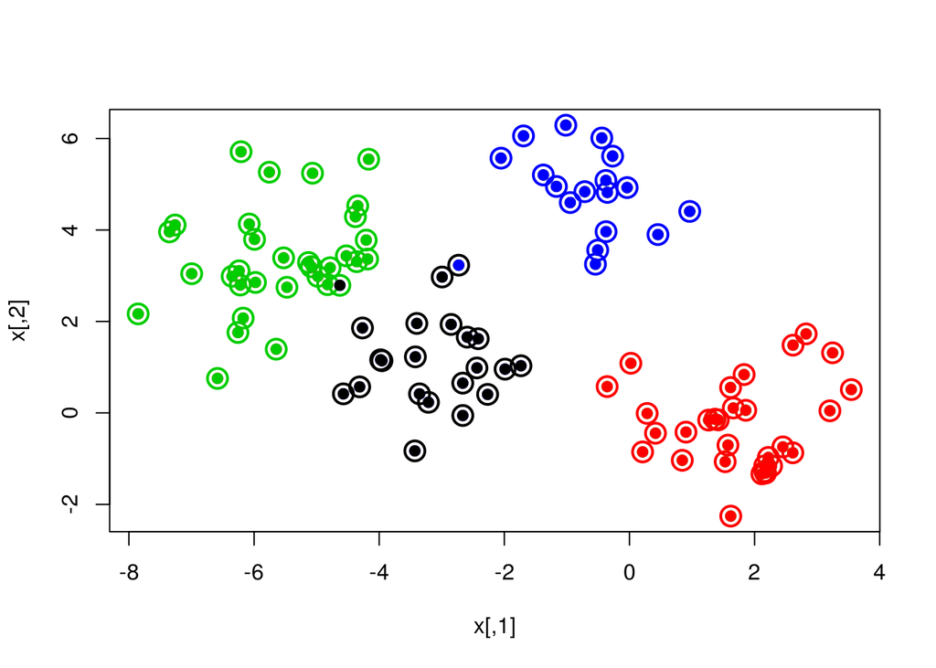

```r
plot(x, col=km.out$cluster, cex=2, pch=1, lwd=2)
points(x, col=which, pch=19) # color mismatch
points(x, col=c(4,3,2,1)[which], pch=19)
```

The plot shows two misclassified points.

# Hierarchical clustering

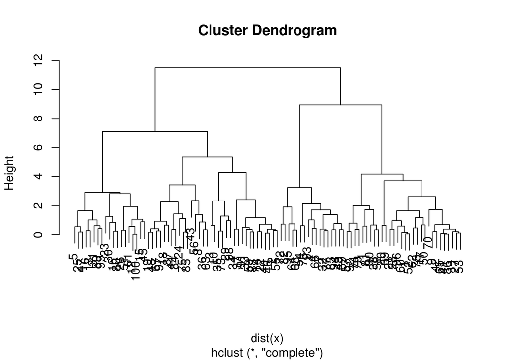

```r
hc.complete <- hclust(dist(x), method='complete')
plot(hc.complete)
```

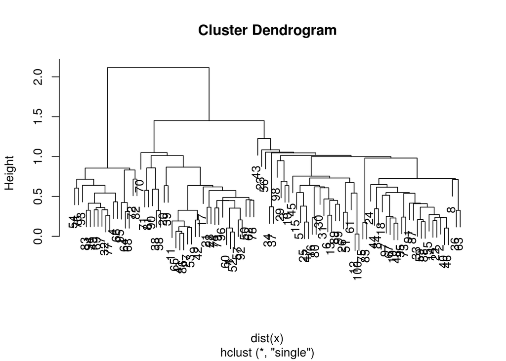

```r
hc.single <- hclust(dist(x), method='single')
plot(hc.single)
```

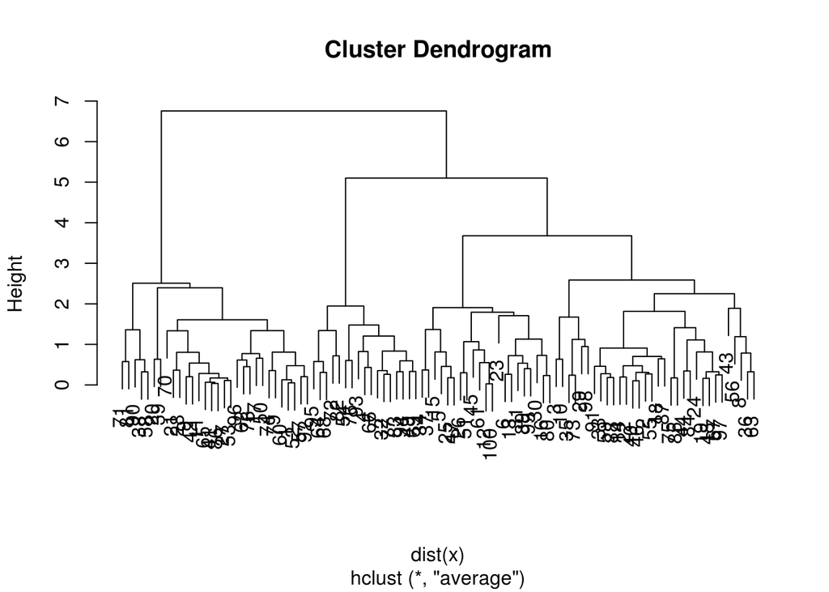

```r
hc.average <- hclust(dist(x), method='average')
plot(hc.average)
```

Comparing output of hierarchical clustering to the actual clusters:

```r
hc.cut <- cutree(hc.complete, k=4)
table(hc.cut, which) # there seem to be 3 obs that were wrongly clustered.
```

```
##       which
## hc.cut  1  2  3  4
##      1  0  0 30  0
##      2  1 31  0  2
##      3 17  0  0  0
##      4  0  0  0 19
```

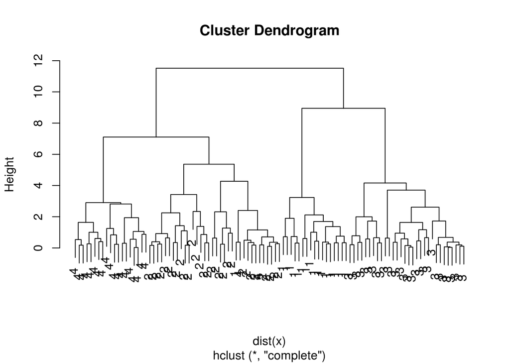

```r
plot(hc.complete, labels=which)
```